# Przestępczość a wypożyczenia rowerów miejskich w danych miejscach Nowego Yorku

Szymon_Kałużny

2022-05-29

# Wstęp

Projekt będzie dotyczył badania zależności między liczbą przestępstw oraz wskaźnikami przestępczości, a popularnością bądź jej brakiem wyboru punktów wypożyczania rowerów w dzień i w nocy. Dane dotyczące rowerów pochodzą z lipca, sierpnia i września 2019 roku.

# Czas popełniania przestępstw

Ciężkie przestępstwa są najczęściej popełniane nocą. Poniżej mamy przykład z statystyką dotyczącą strzelanin na terenie Nowego Yorku od 2006 do 2019 roku.

Stosunek strzelanin dziejących się między 22 a 6 rano w stosunku do liczby wszystkich strzelanin:

[1] 0.5376439

Liczba wszystkich strzelanin mających miejsce nocą:

[1] 11633

Liczba wszystkich strzelanin:

[1] 21637

## Analiza wyników

Ponad połowa strzelanin miała miejsce w godzinach nocnych (między 22 a 6 rano). Czas ten natomiast odpowiada zaledwie 1/3 doby zatem częstotliwość strzelanin w tych godzinach jest ponad 2 razy większa niż w dzień, Prowadzi to do refleksji jaki wskaźnik może pokazywać nam których miejsc unikają rowerzyści z powodów bezpieczeństwa

# Badanie stosunków wypożyczeń rowerów w nocy do wypożyczeń rowerów w dzień

Stosunek ten nazwałem indeksem bezpieczeństwa, zbadamy czy ta nazwa jest adekwatna i czy rzeczywiście tam gdzie jest niebezpiecznie stacja wypożyczeń rowerów ma niski indeks_bezpieczenstwa

## Stacje o najniższym indeksie bezpieczeństwa:

```
##           start.station.name indeksy_bezpieczenstwa
##  1:         Soissons Landing           0.0003726615
##  2:    E 58 St & Madison Ave           0.0045454545
##  3:  Dock 72 Way & Market St           0.0089320388
##  4:          5 Ave & E 73 St           0.0188458262
##  5:          W 52 St & 5 Ave           0.0192614005
##  6:         5 St & Market St           0.0194489465
##  7:      Old Slip & Front St           0.0196839630
##  8: South St & Gouverneur Ln           0.0205783571
##  9:          5 Ave & E 88 St           0.0216207110
## 10:          W 44 St & 5 Ave           0.0224391024
```

### Analiza

Zauważmy, że jest zatem co najmniej 10 stacji z których rowery są wypożyczane aż ponad 40 krotnie częściej w dzień niż w nocy. Istnieje, więc podejrzenie, że miejsca te mogą być niebezpieczne.

## Stacje o najwyższym indeksie bezpieczeństwa:

```
##            start.station.name indeksy_bezpieczenstwa
##  1:         NYCBS Depot - GOW              0.3663102
##  2: Wyckoff Av & Jefferson St              0.2921935
##  3:                      NULL              0.2705882
##  4:   Bushwick Ave & Stagg St              0.2682927
##  5:            21 St & 36 Ave              0.2316911
##  6: Putnam Ave & Nostrand Ave              0.2275055
##  7:     Hart St & Wyckoff Ave              0.2263943
##  8: Greene Ave & Nostrand Ave              0.2226901
##  9:    Union St & Bedford Ave              0.2159233
## 10:    Myrtle Ave & Lewis Ave              0.2098100
```

## Analiza

Przedstawione miejsca są najchętniej odwiedzane w nocy przez użytkowników rowerów, podejrzewamy więc że są one bezpieczne.

## Zlokalizowanie tych charakterystycznych punktów wypożyczeń na mapie i porównanie z mapą ciepła dotyczącą przestępczości

[figure not shown]

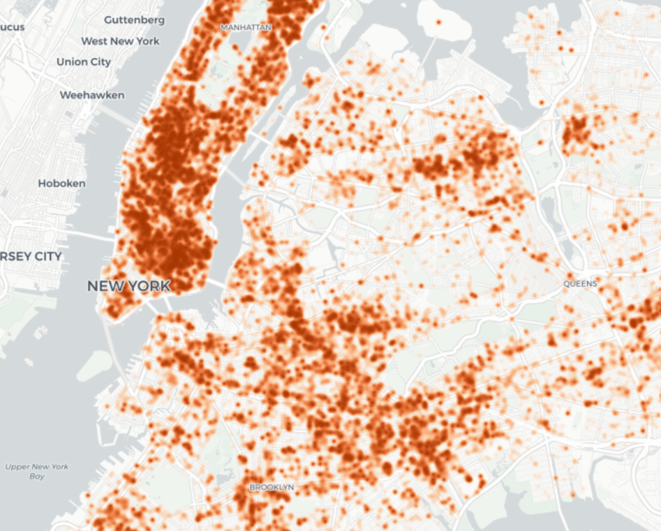

mapa ciepła przestępstw z NYC

## Analiza

Czerwone punkty obrazują miejsca o niskim indeksie bezpieczeństwa co powinno oznaczać że punkty miejsca te są niebezpieczne, natomiast czarne przedstawiają miejsca o wysokim indeksie bezpieczeństwa co powinno objawiać się w małej przestępczości.

Rzeczywiście jesteśmy w stanie zauważyć tą zależność. Nie jest ona doskonała z powodu wyjątkowych miejsc na które działają inne czynniki. Wyjątkami tymi są czerwony punkt na wysepce oraz czerwone punkty na Brooklynie.

# Wykres średnich wartości indeksów bezpieczeństwa dla grup wiekowych i wykres liczby strzelanin, których ofiarami są osoby z danej grupy wiekowej, Analiza zależności

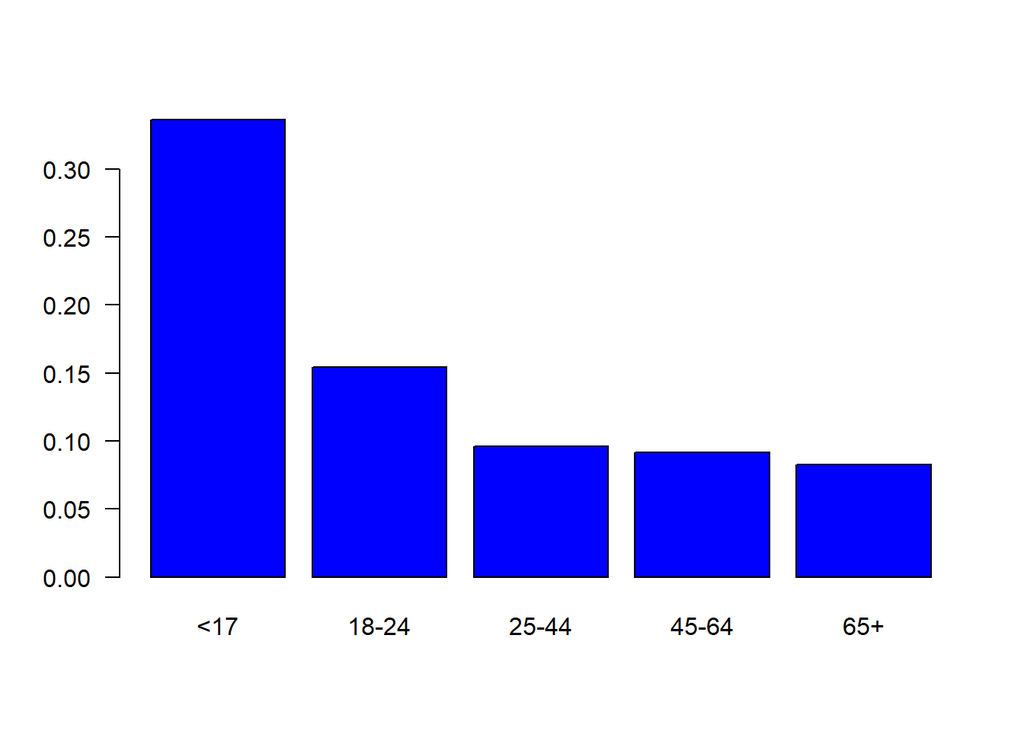

[[1]] [1] 0.33614458 0.15420015 0.09588627 0.09167836 0.08242313

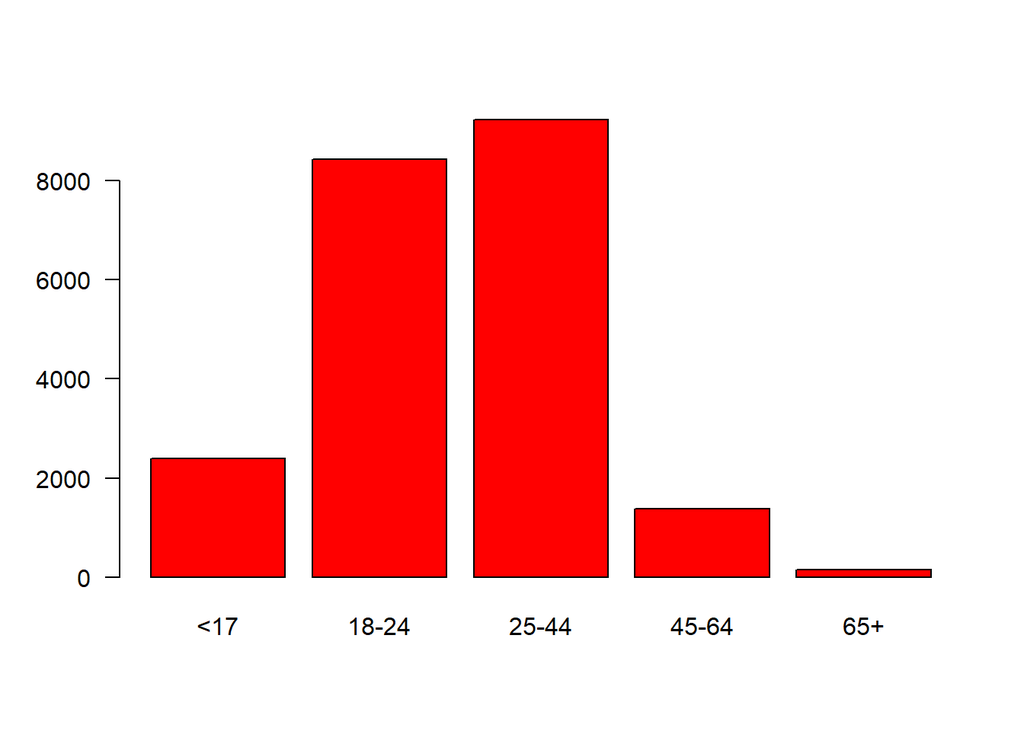

[[1]] [1] 2392 8427 9234 1384 142

## Analiza

Tutaj zależność jest mocno zabużona. przeanalizujmy dlaczego tak jest. Po pierwsze zauważmy że dzieci do 18 roku życia stosunkowo często jeżdżą nocą. Jest to dość nipokojące i może wynikać z braku rozwagi i źle pojmowanej odwagi. Pocieszające jest to że dzieci nie tak często padają ofiarą strzelanin, należy jednak pamiętać że młodzież może być w niebezpieczeństwie, gdyż głównie to strasza grupa dzieci (15+) korzysta z rowerów miejskich.

Zauważmy też że im starsza jest grupa wiekowa tym rzadziej wybiera się gdzieś rowerem w nocy

Według wykresu ogólnie najbardziej zagrożonymi grupami są: 18-24, i 25-44, pamiętając jednak że przedział wiekowy tej pierwszej z nich obejmuje zaledwie 7 lat a liczba strzelanin, w których ofiarą miała być osoba w tym wieku jest porównywalna do analogicznej statystyki w dla grupy 25-44. Zatem osoby w tym wieku są najbardziej narażone, a mimo to często wyjeżdżają nocy

Statystyka ta jest zaburzona gdyż badanie średniej bierze pod uwagę te miejsca w których jest bezpiecznie i one bardziej wpływają na wartość tej średniej.

## Przedstawienie tabelek z najbardziej niebezpiecznymi stacjami oraz posterunków policji o największej liczbie strzelanin dla danej grupy wiekowej

```
##         start.station.name indeksy_bezpieczenstwa
## 1:        12 Ave & W 40 St             0.03174603
## 2:         W 11 St & 6 Ave             0.03571429
## 3:               Cherry St             0.05882353
## 4: Centre St & Chambers St             0.06060606
## 5:      E 13 St & Avenue A             0.06382979
```

```
##     PRECINCT VIC_AGE_GROUP shooting_number
## 313       73           <18             141
## 314       75           <18             136
## 295       44           <18              98
## 318       79           <18              92
## 297       46           <18              89
## 307       67           <18              89
## 291       40           <18              85
## 293       42           <18              77
## 302       52           <18              69
## 298       47           <18              66
```

```
##    start.station.name indeksy_bezpieczenstwa
## 1:    5 Ave & E 78 St             0.02353410
## 2:     48 Ave & 30 Pl             0.02469136
## 3: E 67 St & Park Ave             0.02624672
## 4:    W 52 St & 5 Ave             0.02661979
## 5:    5 Ave & E 73 St             0.02730003
```

```
##     PRECINCT VIC_AGE_GROUP shooting_number
## 388       75         18-24             464
## 387       73         18-24             414
## 381       67         18-24             366
## 366       42         18-24             281
## 392       79         18-24             279
## 368       44         18-24             272
## 371       47         18-24             270
## 370       46         18-24             268
## 367       43         18-24             252
## 364       40         18-24             250
```

```
##          start.station.name indeksy_bezpieczenstwa
## 1:  Dock 72 Way & Market St            0.006207675
## 2:    E 58 St & Madison Ave            0.007812500
## 3:         5 St & Market St            0.011273957
## 4: South St & Gouverneur Ln            0.016428835
## 5:      Old Slip & Front St            0.017273751
```

```
##     PRECINCT VIC_AGE_GROUP shooting_number
## 464       75         25-44             481
## 463       73         25-44             422
## 457       67         25-44             417
## 468       79         25-44             325
## 444       44         25-44             299
## 469       81         25-44             299
## 447       47         25-44             288
## 440       40         25-44             282
## 488      113         25-44             282
## 446       46         25-44             266
```

```
##         start.station.name indeksy_bezpieczenstwa
## 1:        Soissons Landing           0.0006685386
## 2:         5 Ave & E 73 St           0.0155610156
## 3: Dock 72 Way & Market St           0.0170278638
## 4:         5 Ave & E 88 St           0.0195581107
## 5:     Old Slip & Front St           0.0199111404
```

```
##     PRECINCT VIC_AGE_GROUP shooting_number
## 538       73         45-64              61
## 522       47         45-64              58
## 543       79         45-64              54
## 541       77         45-64              49
## 544       81         45-64              47
## 532       67         45-64              46
## 539       75         45-64              44
## 519       44         45-64              37
## 562      113         45-64              35
## 515       40         45-64              30
```

```
##             start.station.name indeksy_bezpieczenstwa
## 1:         Old Slip & Front St            0.007444169
## 2:       E 97 St & Madison Ave            0.009009009
## 3:             E 47 St & 2 Ave            0.009090909
## 4: Greenwich St & W Houston St            0.009740260
## 5:         Murray St & West St            0.009740260
```

```
##     PRECINCT VIC_AGE_GROUP shooting_number
## 587       67           65+               8
## 590       71           65+               7
## 593       75           65+               7
## 251       47           65+               5
## 578       44           65+               4
## 599       88           65+               4
## 600       90           65+               4
## 610      120           65+               4
## 243       32           65+               3
## 246       41           65+               3
```

# analiza otrzymanych wyników

Zauważmy że występują miejsca w których każdy może się czuć zagrożony. Miejscami tymi są między innymi obszar podległy komisariatom o numerach: 44, 47, 75, możemy tak twierdzić, gdyż każdy z tych numerów pojawia się w każdym zestawieniu 10 najniebezpieczniejszych obszarów dla danej grupy wiekowej. Ponadto niebezpieczne są inne miejsca takie jak obszar blisko posterunku 73, 77, i innych niż wymienione komisariaty o numerze z liczbą dziesiątek równą cztery.

### mapka z posterunkami NYC

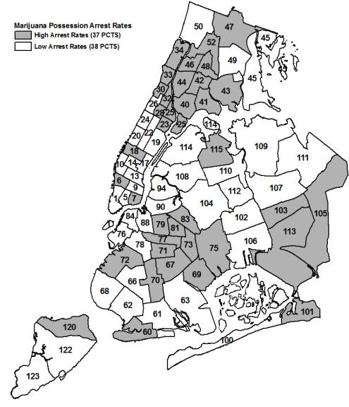

mapka z posterunkami policji nyc

## Charakterystyka miejsc niebezpiecznych dla osób z grupy wiekowej

1. Mapka z najmniejszymi wartościami indeksów bezpieczeństwa

[figure not shown]

[figure not shown]

[figure not shown]

[figure not shown]

[figure not shown]

[figure not shown]

2. Mapka z największymi wartościami indeksów bezpieczeństwa

[figure not shown]

[figure not shown]

[figure not shown]

[figure not shown]

[figure not shown]

[figure not shown]

### Analiza mapek

Pierwsze mapki ukazują że Manhattan jest raczej omijany nocą, Warto też zwrócić uwagę na zróżnicowanie miejsc o niskich indeksach bezpieczenstwa w zależności od grupy wiekowej. Widzimy to między innymi na pierwszej mapce na której widać że występują wszystkie z pięciu kolorów. Ponadto zauważalne jest to, że głównymi miejscami z tymi właściwościami są: południe Manhattanu i jego okolice oraz okolice Central Parku.

Drugie mapki również ukazują duże zróżnicowanie. Należy też dostrzec że miejsca częste i rzadko odwiedzane nocą przez osoby <18 są niedaleko siebie, pokazuje to że dzieci nie boją się jeździć w nocy. Ponadto widzimy że zaznaczone miejsca są skumulowane niedaleko Bushwicku.

# Podsumowanie

W swojej pracy badałem wpływ przestępczości na wybór trasy i rowera miejskiego jako środka transportu w godzinach nocnych. Analiza zależności pomiędzy wskaźnikami dotyczącymi przestępczości oraz wskaźnikami dotyczącymi wypożyczeń rowerów pokazała iż w skali makro taka zależność istnieje i niski “indeks_bezpieczenstwa” świadczy że w danym miejscu często zdarzają się przestępstwa. Z drugiej strony projekt ukazuje, że zależności te są skomplikowane i przy badaniu konkretnych grup wiekowych okazało się że dla niektórych z nich korelacja jest słaba. Wynika stąd, iż pomimo przestępczość jest ważnym czynnikiem wpływającym na podróże nocą to nie jest jedynym istotnym z nich.